# API

```python
#!pip3 install sodapy
```

```python
import pandas as pd
import numpy as np
import urllib.request
import zipfile
import random
import itertools
import math
import matplotlib as mpl
import matplotlib.pyplot as plt
plt.style.use('ggplot')
%matplotlib inline
```

```python
import shapefile
from shapely.geometry import Polygon
from descartes.patch import PolygonPatch
```

```python
# Download the Trip Record Data from January to June
for month in range(1,7):
    urllib.request.urlretrieve("https://s3.amazonaws.com/nyc-tlc/trip+data/"+ \
                               "yellow_tripdata_2020-{0:0=2d}.csv".format(month),
                               "nyc.2020-{0:0=2d}.csv".format(month))

# Download the location Data
urllib.request.urlretrieve("https://s3.amazonaws.com/nyc-tlc/misc/taxi_zones.zip", "taxi_zones.zip")
with zipfile.ZipFile("taxi_zones.zip","r") as zip_ref:
    zip_ref.extractall("./shape")
```

```python
# Download the Trip Record Data from July to December
for month in range(7,13):
    urllib.request.urlretrieve("https://s3.amazonaws.com/nyc-tlc/trip+data/"+ \
                               "yellow_tripdata_2020-{0:0=2d}.csv".format(month),
                               "nyc.2020-{0:0=2d}.csv".format(month))

# Download the location Data
urllib.request.urlretrieve("https://s3.amazonaws.com/nyc-tlc/misc/taxi_zones.zip", "taxi_zones.zip")
with zipfile.ZipFile("taxi_zones.zip","r") as zip_ref:
    zip_ref.extractall("./shape")
```

```python
# import csv into df
df_jan = pd.read_csv("2020_Yellow_Taxi_Trip_Data-01.csv")
len(df_jan)
```

```python
df_feb = pd.read_csv("2020_Yellow_Taxi_Trip_Data-02.csv")
len(df_feb)
```

```python
df_mar = pd.read_csv("2020_Yellow_Taxi_Trip_Data-03.csv")
len(df_mar)
```

```python
df_apr = pd.read_csv("2020_Yellow_Taxi_Trip_Data-04.csv")
len(df_apr)
```

```python
df_may = pd.read_csv("2020_Yellow_Taxi_Trip_Data-05.csv")
len(df_may)
```

```python
df_jun = pd.read_csv("2020_Yellow_Taxi_Trip_Data-06.csv")
len(df_jun)
```

```python
df_jul = pd.read_csv("2020_Yellow_Taxi_Trip_Data-07.csv")
len(df_jul)
```

```python
df_aug = pd.read_csv("2020_Yellow_Taxi_Trip_Data-08.csv")
len(df_aug)
```

```python
df_sept = pd.read_csv("2020_Yellow_Taxi_Trip_Data-09.csv")
len(df_sept)
```

```python
df_oct = pd.read_csv("2020_Yellow_Taxi_Trip_Data-10.csv")
len(df_oct)
```

```python
df_nov = pd.read_csv("2020_Yellow_Taxi_Trip_Data-11.csv")
len(df_nov)
```

```python
df_dec = pd.read_csv("2020_Yellow_Taxi_Trip_Data-12.csv")
len(df_dec)
```

```python
# If you like, you can use this code to download the data from our workspace to your computer
from google.colab import files
files.download('2020_Yellow_Taxi_Trip_Data-01.csv')
```

# 5400 Group Project Report

## 1. Data exploration

```python
import psycopg2, os
import pandas as pd
import matplotlib.pyplot as plt
%matplotlib inline
import numpy as np
```

```python
df = pd.read_csv('2020_Yellow_Taxi_Trip_Data.csv',nrows =10001)
len(df)
df.info()
```

```
<class 'pandas.core.frame.DataFrame'>
RangeIndex: 10001 entries, 0 to 10000
Data columns (total 18 columns):
 #   Column                 Non-Null Count  Dtype
---  ------                 --------------  -----
 0   VendorID               10001 non-null  int64
 1   tpep_pickup_datetime   10001 non-null  object
 2   tpep_dropoff_datetime  10001 non-null  object
 3   passenger_count        10001 non-null  int64
 4   trip_distance          10001 non-null  float64
 5   RatecodeID             10001 non-null  int64
 6   store_and_fwd_flag     10001 non-null  object
 7   PULocationID           10001 non-null  int64
 8   DOLocationID           10001 non-null  int64
 9   payment_type           10001 non-null  int64
 10  fare_amount            10001 non-null  float64
 11  extra                  10001 non-null  float64
 12  mta_tax                10001 non-null  float64
 13  tip_amount             10001 non-null  float64
 14  tolls_amount           10001 non-null  float64
 15  improvement_surcharge  10001 non-null  float64
 16  total_amount           10001 non-null  float64
 17  congestion_surcharge   10001 non-null  float64
dtypes: float64(9), int64(6), object(3)
memory usage: 1.4+ MB
```

```python
df.head()
```

|  | VendorID | tpep_pickup_datetime | tpep_dropoff_datetime | passenger_count | trip_distance | RatecodeID | store_and_fwd_flag | PULocationID | DOLocationID | payment_type | fare_amount | extra | mta_tax | tip_amount | tolls_amount | improvement_surcharge | total_amount | congestion_surcharge |
| --- | --- | --- | --- | --- | --- | --- | --- | --- | --- | --- | --- | --- | --- | --- | --- | --- | --- | --- |
| 0 | 1 | 01/01/2020 12:28:15 AM | 01/01/2020 12:33:03 AM | 1 | 1.2 | 1 | N | 238 | 239 | 1 | 6.0 | 3.0 | 0.5 | 1.47 | 0.0 | 0.3 | 11.27 | 2.5 |
| 1 | 1 | 01/01/2020 12:35:39 AM | 01/01/2020 12:43:04 AM | 1 | 1.2 | 1 | N | 239 | 238 | 1 | 7.0 | 3.0 | 0.5 | 1.50 | 0.0 | 0.3 | 12.30 | 2.5 |
| 2 | 1 | 01/01/2020 12:47:41 AM | 01/01/2020 12:53:52 AM | 1 | 0.6 | 1 | N | 238 | 238 | 1 | 6.0 | 3.0 | 0.5 | 1.00 | 0.0 | 0.3 | 10.80 | 2.5 |
| 3 | 1 | 01/01/2020 12:55:23 AM | 01/01/2020 01:00:14 AM | 1 | 0.8 | 1 | N | 238 | 151 | 1 | 5.5 | 0.5 | 0.5 | 1.36 | 0.0 | 0.3 | 8.16 | 0.0 |
| 4 | 2 | 01/01/2020 12:01:58 AM | 01/01/2020 12:04:16 AM | 1 | 0.0 | 1 | N | 193 | 193 | 2 | 3.5 | 0.5 | 0.5 | 0.00 | 0.0 | 0.3 | 4.80 | 0.0 |

- PULocation ID and DOLocation ID is a numerical key which refer to pick up location and drop off location when we combine it with location dataset.
- Passenger_count refers to the number of customers in that specific ride.
- Tpep_pickup_datetime is the time which ride starts.
- Tip_amount is the tip that was given from the customer.
- Trip_distance refers to the distance of the ride

```python
df_zones = pd.read_csv('taxi_zones.csv')
df_zones.info()
```

```
<class 'pandas.core.frame.DataFrame'>
RangeIndex: 263 entries, 0 to 262
Data columns (total 8 columns):
 #   Column      Non-Null Count  Dtype
---  ------      --------------  -----
 0   OBJECTID    263 non-null    int64
 1   Shape_Leng  263 non-null    float64
 2   Shape_Area  263 non-null    float64
 3   zone        263 non-null    object
 4   LocationID  263 non-null    int64
 5   borough     263 non-null    object
 6   Longitude   263 non-null    float64
 7   Latitude    263 non-null    float64
dtypes: float64(4), int64(2), object(2)
memory usage: 16.6+ KB
```

```python
df_zones.head()
```

|  | OBJECTID | Shape_Leng | Shape_Area | zone | LocationID | borough | Longitude | Latitude |
| --- | --- | --- | --- | --- | --- | --- | --- | --- |
| 0 | 1 | 0.116357 | 0.000782 | Newark Airport | 1 | EWR | -74.184453 | 40.694996 |
| 1 | 2 | 0.433470 | 0.004866 | Jamaica Bay | 2 | Queens | -73.823376 | 40.638987 |
| 2 | 3 | 0.084341 | 0.000314 | Allerton/Pelham Gardens | 3 | Bronx | -73.847926 | 40.871342 |
| 3 | 4 | 0.043567 | 0.000112 | Alphabet City | 4 | Manhattan | -73.971774 | 40.725821 |
| 4 | 5 | 0.092146 | 0.000498 | Arden Heights | 5 | Staten Island | -74.174217 | 40.562568 |

```python
import folium
service_area = folium.Map(
    location = [40.712776, -74.005974],
    zoom_start = 10)

for i in range(len(df_do1)):
    folium.Marker(
        location = [df_do1['Latitude'][i],df_do1['Longitude'][i]]).add_to(service_area)
service_area
```

Make this Notebook Trusted to load map: File -> Trust Notebook

[interactive chart not shown]

There are 8 variables in the taxi zones dataset and 263 observations.

- LocationID correspond to the PULocation ID and DOLocation ID.
- Zone and Borough provides the Location name.

## 2. Connect to the local Postgre SQL databased running as Docker container

```python
import psycopg2, os
print('Connecting to the PostgreSQL database...')
conn = psycopg2.connect(
    host="localhost",
    port='5432',
    database="postgres",
    user="postgres",
    password="123")
```

```
Connecting to the PostgreSQL database...
```

```python
# create a cursor
cur = conn.cursor()
```

### Create tables

```python
 createtaxi_2020 = """ CREATE TABLE if not exists taxi_2020 (
                  ID SERIAL PRIMARY KEY,
                  VendorID INT,
                  tpep_pickup_datetime TIMESTAMP,
                  tpep_dropoff_datetimedate TIMESTAMP,
                  passenger_count INT,
                  trip_distance FLOAT,
                  RatecodeID INT,
                  store_and_fwd_flag VARCHAR(255),
                  PULocationID INT,
                  DOLocationID INT,
                  payment_type INT,
                  fare_amount FLOAT,
                  extra FLOAT,
                  mta_tax  FLOAT,
                  tip_amount FLOAT,
                  tolls_amount FLOAT,
                  improvement_surcharge FLOAT,
                  total_amount FLOAT,
                  congestion_surcharge FLOAT
                  )
              """

cur.execute(createtaxi_2020)
conn.commit()
```

```python
createtaxi_zones = """CREATE TABLE if not exists taxi_zones (
                   OBJECTID INT,
                   Shape_Leng FLOAT,
                   Shape_Area FLOAT,
                   zone VARCHAR(255),
                   LocationID INT,
                   borough VARCHAR(255),
                   Longitude FLOAT,
                   Latitude  FLOAT,
                   PRIMARY KEY(OBJECTID)
                   )"""
cur.execute(createtaxi_zones)
conn.commit()
```

# Business Use Case

## Q1 The most pick up and drop off locations

```python
# the top 10 most pick up locations
pu = """
SELECT taxi_2020.PULocationID, taxi_zones.zone, taxi_zones.borough, taxi_zones.Longitude, taxi_zones.Latitude, count(*)
FROM taxi_2020
JOIN taxi_zones ON taxi_2020.PULocationID = taxi_zones.OBJECTID
GROUP BY 1,2,3,4,5
        """
cur.execute(pu)
df_pu1 = pd.DataFrame(cur.fetchall(),columns=["LocationID","zone",'borough','Longitude','Latitude','PUCount']).sort_values('PUCount',ascending=False)
df_pu1.head(10)
```

|  | LocationID | zone | borough | Longitude | Latitude | PUCount |
| --- | --- | --- | --- | --- | --- | --- |
| 233 | 237 | Upper East Side South | Manhattan | -73.966127 | 40.762179 | 1135070 |
| 232 | 236 | Upper East Side North | Manhattan | -73.957794 | 40.773600 | 1078295 |
| 157 | 161 | Midtown Center | Manhattan | -73.975344 | 40.755300 | 940528 |
| 182 | 186 | Penn Station/Madison Sq West | Manhattan | -73.990968 | 40.745421 | 857246 |
| 158 | 162 | Midtown East | Manhattan | -73.971217 | 40.755193 | 826119 |
| 166 | 170 | Murray Hill | Manhattan | -73.972033 | 40.745805 | 745744 |
| 138 | 142 | Lincoln Square East | Manhattan | -73.981479 | 40.767725 | 740054 |
| 47 | 48 | Clinton East | Manhattan | -73.991177 | 40.755330 | 723712 |
| 235 | 239 | Upper West Side South | Manhattan | -73.975014 | 40.787686 | 697198 |
| 226 | 230 | Times Sq/Theatre District | Manhattan | -73.983624 | 40.755516 | 684783 |

```python
#Viz for most pick up location
import folium
most_pick = folium.Map(
    location = [40.712776, -74.005974],
    zoom_start = 10)

for i in range(10):
    folium.Marker(
        location = [df_pu1['Latitude'][i],df_pu1['Longitude'][i]]).add_to(most_pick)
most_pick
```

Make this Notebook Trusted to load map: File -> Trust Notebook

[interactive chart not shown]

```python
# the top 10 most drop off locations
do = """
SELECT taxi_2020.DOLocationID, taxi_zones.zone, taxi_zones.borough, taxi_zones.Longitude, taxi_zones.Latitude, count(*)
FROM taxi_2020
JOIN taxi_zones ON taxi_2020.DOLocationID = taxi_zones.OBJECTID
GROUP BY 1,2,3,4,5
        """
cur.execute(do)
df_do1 = pd.DataFrame(cur.fetchall(),columns=["LocationID","zone",'borough','Longitude','Latitude','DOCount']).sort_values('DOCount',ascending=False)
df_do1.head(10)
```

|  | LocationID | zone | borough | Longitude | Latitude | DOCount |
| --- | --- | --- | --- | --- | --- | --- |
| 233 | 236 | Upper East Side North | Manhattan | -73.957794 | 40.773600 | 1115222 |
| 234 | 237 | Upper East Side South | Manhattan | -73.966127 | 40.762179 | 1006202 |
| 158 | 161 | Midtown Center | Manhattan | -73.975344 | 40.755300 | 837702 |
| 167 | 170 | Murray Hill | Manhattan | -73.972033 | 40.745805 | 730463 |
| 138 | 141 | Lenox Hill West | Manhattan | -73.961777 | 40.759880 | 680109 |
| 139 | 142 | Lincoln Square East | Manhattan | -73.981479 | 40.767725 | 664519 |
| 236 | 239 | Upper West Side South | Manhattan | -73.975014 | 40.787686 | 661555 |
| 159 | 162 | Midtown East | Manhattan | -73.971217 | 40.755193 | 661108 |
| 47 | 48 | Clinton East | Manhattan | -73.991177 | 40.755330 | 634834 |
| 235 | 238 | Upper West Side North | Manhattan | -73.968844 | 40.785967 | 601110 |

```python
#Viz for most drop off location
import folium
most_drop = folium.Map(
    location = [40.712776, -74.005974],
    zoom_start = 10)

for i in range(10):
    folium.Marker(
        location = [df_do1['Latitude'][i],df_do1['Longitude'][i]]).add_to(most_drop)
most_pick
```

Make this Notebook Trusted to load map: File -> Trust Notebook

[interactive chart not shown]

## Q2 When are Peak times and when are Off Peak times

```python
query1 = ('''SELECT EXTRACT(HOUR FROM "tpep_pickup_datetime") pickup_hour, count(*) AS PUHcount
              FROM taxi_2020
              GROUP BY pickup_hour
              ORDER BY PUHcount DESC''')

cur.execute(query1)
data_puh1 = cur.fetchall()
data_puh1 = pd.DataFrame(data_puh1)

query2 = ('''SELECT EXTRACT(HOUR FROM "tpep_dropoff_datetimedate") dropoff_hour, count(*) AS DOHcount
              FROM taxi_2020
              GROUP BY dropoff_hour
              ORDER BY DOHcount DESC''')
cur.execute(query2)
data_doh1 = cur.fetchall()
data_doh1 = pd.DataFrame(data_doh1)

#Rename colnames
data_puh1.columns = ["Hour","Pick-up-hours"]
data_doh1.columns = ["Hour","Drop-off-hours"]

df_hour2= pd.merge(data_puh1, data_doh1, on = 'Hour',how = 'right')
df_hour2
```

|  | Hour | Pick-up-hours | Drop-off-hours |
| --- | --- | --- | --- |
| 0 | 18 | 1664466 | 1693450 |
| 1 | 17 | 1608764 | 1580305 |
| 2 | 15 | 1567504 | 1563507 |
| 3 | 19 | 1449693 | 1529282 |
| 4 | 16 | 1494776 | 1496915 |
| 5 | 14 | 1537716 | 1496812 |
| 6 | 13 | 1440682 | 1419389 |
| 7 | 12 | 1401047 | 1389259 |
| 8 | 11 | 1286086 | 1261333 |
| 9 | 20 | 1210653 | 1243979 |
| 10 | 10 | 1209434 | 1205853 |
| 11 | 9 | 1172671 | 1178296 |
| 12 | 21 | 1125763 | 1136466 |
| 13 | 8 | 1148603 | 1093592 |
| 14 | 22 | 1010743 | 1045190 |
| 15 | 23 | 765161 | 820681 |
| 16 | 7 | 873359 | 779826 |
| 17 | 0 | 530072 | 580893 |
| 18 | 6 | 486678 | 428942 |
| 19 | 1 | 364001 | 392810 |
| 20 | 2 | 248590 | 267485 |
| 21 | 3 | 183246 | 191698 |
| 22 | 5 | 193818 | 173473 |
| 23 | 4 | 151694 | 155784 |

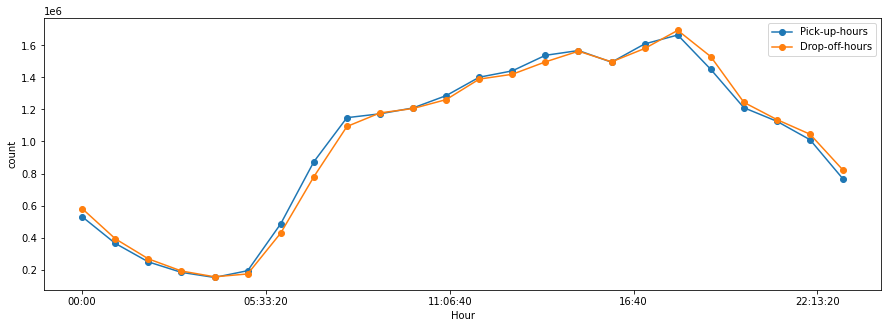

```python
#Visualization
df_hour2['Hour'] = pd.to_datetime(df_hour2['Hour'],format='%H').dt.time
ax = df_hour2.plot(x='Hour', y=['Pick-up-hours', 'Drop-off-hours'], kind='line', style="-o", figsize=(15,5))
ax.set_ylabel("count")
plt.show()
```

### The peak time is 6 pm to 7 pm in the evening, and the off-peak time is 4 am to 5 am in the early morning for both pick-up and drop-off.

## Q3 Average passenger volume per car for each time period

```python
query3 = ('''SELECT EXTRACT(HOUR FROM "tpep_pickup_datetime") pickup_hour,sum(passenger_count)/count(*) AS avg_flow_pickup
              FROM taxi_2020
              GROUP BY pickup_hour
              ORDER BY avg_flow_pickup DESC''')
cur.execute(query3)
data_flow = cur.fetchall()
data_flow = pd.DataFrame(data_flow)
```

```python
data_flow.columns = ["Time","Flow"]
data_flow
```

|  | Time | Flow |
| --- | --- | --- |
| 0 | 0 | 1 |
| 1 | 1 | 1 |
| 2 | 2 | 1 |
| 3 | 3 | 1 |
| 4 | 4 | 1 |
| 5 | 5 | 1 |
| 6 | 6 | 1 |
| 7 | 7 | 1 |
| 8 | 8 | 1 |
| 9 | 9 | 1 |
| 10 | 10 | 1 |
| 11 | 11 | 1 |
| 12 | 12 | 1 |
| 13 | 13 | 1 |
| 14 | 14 | 1 |
| 15 | 15 | 1 |
| 16 | 16 | 1 |
| 17 | 17 | 1 |
| 18 | 18 | 1 |
| 19 | 19 | 1 |
| 20 | 20 | 1 |
| 21 | 21 | 1 |
| 22 | 22 | 1 |
| 23 | 23 | 1 |

### The average passenger volume per car of each period equals 1.

## Q4 What type of ride tend to receive tips from passenger? (Long or Short Distance, Hot Zone, Peak Hours)?

```python
# Some outliers in the data need to be discarded
sql1 = ('''SELECT trip_distance
            FROM taxi_2020
            WHERE trip_distance >0 and trip_distance < 1500 ''')
cur.execute(sql1)

data = cur.fetchall()
data = pd.DataFrame(data)
data
```

|  | 0 |
| --- | --- |
| 0 | 1.20 |
| 1 | 1.20 |
| 2 | 0.60 |
| 3 | 0.80 |
| 4 | 0.03 |
| ... | ... |
| 23800909 | 11.30 |
| 23800910 | 2.18 |
| 23800911 | 2.52 |
| 23800912 | 0.59 |
| 23800913 | 6.06 |

23800914 rows × 1 columns

### Define short and long distance

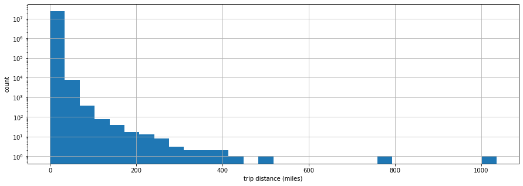

```python
#The distrubution of trip_distance

ax = data[0].hist(bins=30, figsize=(15,5))
ax.set_yscale('log')
ax.set_xlabel("trip distance (miles)")
ax.set_ylabel("count")
plt.show()
```

```python
# Based on the distribution of trip distances and the fact that it would take about 30 miles to drive across the entirety of New York City,\
# we decided to use 30 as the criterion to classify trips as short or long distancce

sql_short = ('''SELECT count(*) AS ST_Count, avg(tip_amount) AS ST_Tips
                FROM taxi_2020
                WHERE trip_distance <= 30''')

cur.execute(sql_short)
data_short = cur.fetchone()
data_short = pd.DataFrame(data_short).transpose()

sql_long = ('''SELECT count(*) AS LT_Count, avg(tip_amount) AS LT_Tips
                FROM taxi_2020
                WHERE trip_distance > 30''')

cur.execute(sql_long)
data_long = cur.fetchone()
data_long = pd.DataFrame(data_long).transpose()
```

```python
#Compare short distance and long distance
frames =[data_short, data_long]
df_dist = pd.concat(frames)

df_dist.columns = ["Count","Average_Tips"]
df_dist.index = ["Short_Distance","Long_Distance"]
df_dist
```

|  | Count | Average_Tips |
| --- | --- | --- |
| Short_Distance | 24110919.0 | 2.071809 |
| Long_Distance | 14301.0 | 10.816116 |

#### Drivers receive more tips for longer distance trips.

### Tips on pick-ups and drop-offs region

```python
sql_pul = ('''SELECT t.PULocationID, z.zone, z.borough, z.Longitude, z.Latitude, count(*) AS PUcount,avg(t.tip_amount) tips
              FROM taxi_2020 t
              INNER JOIN taxi_zones z
              ON z.LocationID = t.PULocationID
              GROUP BY t.PULocationID,zone,borough,Longitude,Latitude
              ORDER BY PUcount DESC, tips DESC
              limit 10
              ''')
cur.execute(sql_pul)
data_pul = cur.fetchall()
data_pul = pd.DataFrame(data_pul)

sql_dol = ('''SELECT t.DOLocationID, z.zone, z.borough, z.Longitude, z.Latitude, count(*) AS DOcount,avg(t.tip_amount) tips
              FROM taxi_2020 t
              INNER JOIN taxi_zones z
              ON z.LocationID = t.DOLocationID
              GROUP BY t.DOLocationID,zone,borough,Longitude,Latitude
              ORDER BY DOcount DESC, tips DESC
              limit 10
              ''')
cur.execute(sql_dol)
data_dol = cur.fetchall()
data_dol = pd.DataFrame(data_dol)

#Rename colnames
data_pul.columns = ["LocationId","Zone","Borough","Longitude","Latitude", "PUL_Count","Average_Tips"]
data_dol.columns = ["LocationId","Zone","Borough","Longitude","Latitude", "DOL_Count","Average_Tips"]
```

```python
data_pul
```

|  | LocationId | Zone | Borough | Longitude | Latitude | PUL_Count | Average_Tips |
| --- | --- | --- | --- | --- | --- | --- | --- |
| 0 | 237 | Upper East Side South | Manhattan | -73.966127 | 40.762179 | 1135070 | 1.745729 |
| 1 | 236 | Upper East Side North | Manhattan | -73.957794 | 40.773600 | 1078295 | 1.812351 |
| 2 | 161 | Midtown Center | Manhattan | -73.975344 | 40.755300 | 940528 | 2.108875 |
| 3 | 186 | Penn Station/Madison Sq West | Manhattan | -73.990968 | 40.745421 | 857246 | 2.000661 |
| 4 | 162 | Midtown East | Manhattan | -73.971217 | 40.755193 | 826119 | 2.103710 |
| 5 | 170 | Murray Hill | Manhattan | -73.972033 | 40.745805 | 745744 | 2.014649 |
| 6 | 142 | Lincoln Square East | Manhattan | -73.981479 | 40.767725 | 740054 | 1.898398 |
| 7 | 48 | Clinton East | Manhattan | -73.991177 | 40.755330 | 723712 | 1.803680 |
| 8 | 239 | Upper West Side South | Manhattan | -73.975014 | 40.787686 | 697198 | 1.899456 |
| 9 | 230 | Times Sq/Theatre District | Manhattan | -73.983624 | 40.755516 | 684783 | 2.112811 |

```python
data_dol
```

|  | LocationId | Zone | Borough | Longitude | Latitude | DOL_Count | Average_Tips |
| --- | --- | --- | --- | --- | --- | --- | --- |
| 0 | 236 | Upper East Side North | Manhattan | -73.957794 | 40.773600 | 1115222 | 1.804790 |
| 1 | 237 | Upper East Side South | Manhattan | -73.966127 | 40.762179 | 1006202 | 1.710948 |
| 2 | 161 | Midtown Center | Manhattan | -73.975344 | 40.755300 | 837702 | 1.859522 |
| 3 | 170 | Murray Hill | Manhattan | -73.972033 | 40.745805 | 730463 | 1.912163 |
| 4 | 141 | Lenox Hill West | Manhattan | -73.961777 | 40.759880 | 680109 | 1.816658 |
| 5 | 142 | Lincoln Square East | Manhattan | -73.981479 | 40.767725 | 664519 | 1.864255 |
| 6 | 239 | Upper West Side South | Manhattan | -73.975014 | 40.787686 | 661555 | 1.975780 |
| 7 | 162 | Midtown East | Manhattan | -73.971217 | 40.755193 | 661108 | 1.964260 |
| 8 | 48 | Clinton East | Manhattan | -73.991177 | 40.755330 | 634834 | 1.775602 |
| 9 | 238 | Upper West Side North | Manhattan | -73.968844 | 40.785967 | 601110 | 1.966983 |

```python
# The average tips in top 10 pick-up area
import folium
from folium.plugins import HeatMap

most_tips_pick = folium.Map(location = [40.712776, -74.005974],
                       zoom_start = 12,
                       width='100%',
                       height='100%')

heatdata = data_pul[['Latitude','Longitude','Average_Tips']].values.tolist()

HeatMap(heatdata).add_to(most_tips_pick)

most_tips_pick
```

Make this Notebook Trusted to load map: File -> Trust Notebook

[interactive chart not shown]

```python
# The average tips in top 10 drop-off area
import folium
from folium.plugins import HeatMap

most_tips_drop = folium.Map(location = [40.712776, -74.005974],
                       zoom_start = 12,
                       width='100%',
                       height='100%')

heatdata = data_dol[['Latitude','Longitude','Average_Tips']].values.tolist()

HeatMap(heatdata).add_to(most_tips_drop)

most_tips_drop
```

Make this Notebook Trusted to load map: File -> Trust Notebook

[interactive chart not shown]

### Tips on pickups and drop-offs hours

```python
sql_puh = ('''SELECT EXTRACT(HOUR FROM "tpep_pickup_datetime") pickup_hour, count(*) AS PUHcount,avg(tip_amount) tips
              FROM taxi_2020
              GROUP BY pickup_hour
              ORDER BY pickup_hour,tips DESC, PUHcount DESC''')
cur.execute(sql_puh)
data_puh = cur.fetchall()
data_puh = pd.DataFrame(data_puh)

sql_doh = ('''SELECT EXTRACT(HOUR FROM "tpep_dropoff_datetimedate") dropoff_hour, count(*) AS DOHcount,avg(tip_amount) tips
              FROM taxi_2020
              GROUP BY dropoff_hour
              ORDER BY dropoff_hour,tips DESC,DOHcount DESC ''')
cur.execute(sql_doh)
data_doh = cur.fetchall()
data_doh = pd.DataFrame(data_doh)

#Rename colnames
data_puh.columns = ["Hour","PUH_Count","PUH_Average Tips"]
data_doh.columns = ["Hour","DOH_Count","DOH_Average Tips"]
```

```python
#Merge both dataframe
df_hour = pd.merge(data_puh, data_doh, on = 'Hour',how = 'right')
df_hour
```

|  | Hour | PUH_Count | PUH_Average Tips | DOH_Count | DOH_Average Tips |
| --- | --- | --- | --- | --- | --- |
| 0 | 0 | 530072 | 2.216868 | 580893 | 2.298058 |
| 1 | 1 | 364001 | 2.012513 | 392810 | 2.149187 |
| 2 | 2 | 248590 | 1.860968 | 267485 | 1.937376 |
| 3 | 3 | 183246 | 1.814251 | 191698 | 1.845966 |
| 4 | 4 | 151694 | 1.829889 | 155784 | 1.771793 |
| 5 | 5 | 193818 | 2.171814 | 173473 | 1.978726 |
| 6 | 6 | 486678 | 1.879893 | 428942 | 1.818839 |
| 7 | 7 | 873359 | 1.943459 | 779826 | 1.856173 |
| 8 | 8 | 1148603 | 2.019353 | 1093592 | 1.963274 |
| 9 | 9 | 1172671 | 1.982966 | 1178296 | 2.015492 |
| 10 | 10 | 1209434 | 1.933316 | 1205853 | 1.936643 |
| 11 | 11 | 1286086 | 1.903868 | 1261333 | 1.904042 |
| 12 | 12 | 1401047 | 1.918844 | 1389259 | 1.897928 |
| 13 | 13 | 1440682 | 1.946344 | 1419389 | 1.909298 |
| 14 | 14 | 1537716 | 1.998399 | 1496812 | 1.952594 |
| 15 | 15 | 1567504 | 2.027524 | 1563507 | 1.988997 |
| 16 | 16 | 1494776 | 2.158176 | 1496915 | 2.119783 |
| 17 | 17 | 1608764 | 2.176533 | 1580305 | 2.182405 |
| 18 | 18 | 1664466 | 2.183799 | 1693450 | 2.207784 |
| 19 | 19 | 1449693 | 2.166748 | 1529282 | 2.219665 |
| 20 | 20 | 1210653 | 2.250989 | 1243979 | 2.244438 |
| 21 | 21 | 1125763 | 2.306473 | 1136466 | 2.322331 |
| 22 | 22 | 1010743 | 2.341811 | 1045190 | 2.355187 |
| 23 | 23 | 765161 | 2.257178 | 820681 | 2.343814 |

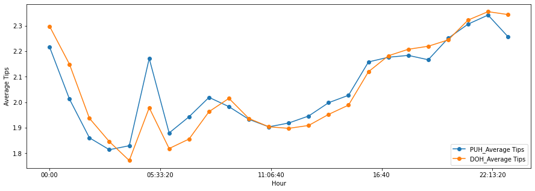

```python
#Visualization
#Compare with the Peak times and Off Peak times figure
df_hour['Hour'] = pd.to_datetime(df_hour['Hour'],format='%H').dt.time
ax = df_hour.plot(x='Hour', y=['PUH_Average Tips', 'DOH_Average Tips'], kind='line', style="-o", figsize=(15,5))
ax.set_ylabel("Average Tips")
plt.show()
```

#### Drivers receive more tips in late night.

```python
# close the communication with the PostgreSQL
# cur.close()
# conn.close()
```